# M512B

## Data Visualisation and Communication (WS1225)

### *Individual Final Project*

**Student Name**: Anh Tuan Ta  
**Student ID**: GH1046139.  
**Student Email**: anh.ta@gisma-student.com  
**LinkedIn**: https://www.linkedin.com/in/ta-anh-tuan-ai-engineer

MSc of DATA SCIENCE, AI AND DIGITAL BUSINESS

## Hotel Booking Demand — Pricing & Cancellation Insights for Revenue Management

**Dataset:** *Hotel Booking Demand* (City & Resort hotels)

**Accessed:** 2026-03-06

## Project introduction

### Audience (who this is for)

This notebook is written for a **hotel revenue and operations team**, especially:

- **Revenue Manager**
- **Distribution Manager**
- **Operations / inventory planning team**

### Business context

Hotels do not just need bookings — they need the **right bookings**.

A useful booking should bring a good room rate, be reasonably reliable, and fit the hotel’s operational capacity. In practice, that means the hotel needs to balance:

- **price** (ADR)
- **cancellation risk**
- **segment quality**
- **seasonality**
- **operational pressure**

This dataset includes historical bookings for **City** and **Resort** hotels, with information on ADR, lead time, market segment, room type, and cancellations. That makes it possible to study not only how rooms are priced, but also which bookings are more valuable and where the hotel faces avoidable risk.

### What you should be able to do after reading

After reading this notebook, the client should be able to:

- understand the hotel’s **normal ADR range**
- see why **City and Resort hotels should not be managed the same way**
- identify when **pricing pressure** and **demand load** are highest
- spot where **cancellation risk** becomes dangerous
- see which **market segments** are stronger or weaker
- identify where **room allocation pressure** is highest
- translate these patterns into a few clear business actions

### Main story of this analysis

The main idea is simple:

**City and Resort hotels behave differently, and the hotel should not use one shared pricing and booking strategy for both.**

The charts show this from different angles:

- the hotel has a clear **typical ADR band**
- **City ADR** is generally higher than **Resort ADR**
- **Resort pricing** is much more seasonal
- **long-lead bookings** are much riskier
- some **segments** are stronger than others once cancellation is considered
- some **room types** create more operational pressure
- demand load is **not flat through the year**

### Core questions

1. What does the hotel’s **typical ADR** look like?
2. How do **City and Resort hotels** differ in price level and seasonality?
3. When does **cancellation risk** become serious?
4. Which **market segments** bring the best mix of price and reliability?
5. Where does the hotel face the most **operational pressure**?
6. How should the hotel adjust **pricing, inventory, and planning** based on these patterns?

## 1. Library Import

```python
import warnings
warnings.filterwarnings("ignore")

import numpy as np
import pandas as pd
import matplotlib.pyplot as plt

from matplotlib.lines import Line2D
```

```python
HILITE = "#7A0C0C"     # deep red
MUTED = "lightgray"
TEXT_GRAY = "gray"

RED_HIGHLIGHT = "#8B0F0F"

CITY = "#0072B2"
RESORT = "#D55E00"
GRID = "#DADADA"
```

```python
SOURCE_NAME = "Hotel Booking Demand dataset (Antonio, Almeida, Nunes; Data in Brief)"
DATA_URL = "https://raw.githubusercontent.com/mpolinowski/hotel-booking-dataset/master/datasets/hotel_bookings.csv"
ACCESS_DATE = "2026-03-06"
```

```python
plt.rcParams.update({
    "figure.dpi": 120,
    "axes.titlesize": 14,
    "axes.labelsize": 11,
    "xtick.labelsize": 10,
    "ytick.labelsize": 10,
    "legend.fontsize": 10
})
```

## 2. Load data

```python
LOCAL_DATA_PATH = "hotel_bookings.csv"
```

```python
df = pd.read_csv(LOCAL_DATA_PATH)

print("Rows, columns:", df.shape)
df.head(3)
```

```
Rows, columns: (119390, 32)
```

|  | hotel | is_canceled | lead_time | arrival_date_year | arrival_date_month | arrival_date_week_number | arrival_date_day_of_month | stays_in_weekend_nights | stays_in_week_nights | adults | ... | deposit_type | agent | company | days_in_waiting_list | customer_type | adr | required_car_parking_spaces | total_of_special_requests | reservation_status | reservation_status_date |
| --- | --- | --- | --- | --- | --- | --- | --- | --- | --- | --- | --- | --- | --- | --- | --- | --- | --- | --- | --- | --- | --- |
| 0 | Resort Hotel | 0 | 342 | 2015 | July | 27 | 1 | 0 | 0 | 2 | ... | No Deposit | NaN | NaN | 0 | Transient | 0.0 | 0 | 0 | Check-Out | 01-07-15 |
| 1 | Resort Hotel | 0 | 737 | 2015 | July | 27 | 1 | 0 | 0 | 2 | ... | No Deposit | NaN | NaN | 0 | Transient | 0.0 | 0 | 0 | Check-Out | 01-07-15 |
| 2 | Resort Hotel | 0 | 7 | 2015 | July | 27 | 1 | 0 | 1 | 1 | ... | No Deposit | NaN | NaN | 0 | Transient | 75.0 | 0 | 0 | Check-Out | 02-07-15 |

3 rows × 32 columns

## 3. Data cleaning + feature engineering

### Data characteristics and quality issues

Before building the charts, it is important to understand what this dataset looks like and what needs to be cleaned.

This dataset contains hotel booking records for **City** and **Resort** hotels. It includes useful business variables such as **ADR, lead time, market segment, room type, arrival date, stay length, and cancellation status**, which makes it suitable for pricing, demand, and operational analysis.

At the same time, a few data issues need attention before visualization:

- **ADR contains some extreme values**, which can distort charts and make the normal price range harder to see.
- **Arrival month is stored as text**, so it needs to be converted into a numeric month for time-based analysis.
- **Arrival date is split across several columns**, so it needs to be combined into one proper date field.
- **Some charts need derived variables**, such as total stay nights, lead-time bins, and clipped ADR.
- **Missing values need to be handled carefully**, depending on which variables are used in each chart.

These preprocessing steps are not only technical. They help make the visuals fairer, easier to read, and more useful for business decisions.

### Standardize month names -> month number

```python
month_map = {
    "January":1, "February":2, "March":3, "April":4, "May":5, "June":6,
    "July":7, "August":8, "September":9, "October":10, "November":11, "December":12
}
df["arrival_month"] = df["arrival_date_month"].map(month_map)
```

### Arrival date (good for time series)

```python
df["arrival_date"] = pd.to_datetime(
    dict(year=df["arrival_date_year"], month=df["arrival_month"], day=df["arrival_date_day_of_month"]),
    errors="coerce"
)
```

```python
# Stay length
df["stay_nights"] = df["stays_in_weekend_nights"] + df["stays_in_week_nights"]
```

### ADR (Average Daily Rate): keep non-negative

```python
df = df[df["adr"].notna()]
df = df[df["adr"] >= 0]
```

```python
# Clip ADR to avoid outliers dominating charts
adr_cap = df["adr"].quantile(0.99)
df["adr_clip"] = df["adr"].clip(upper=adr_cap)
```

### Helpful bins

```python
df["lead_time_bin"] = pd.cut(
    df["lead_time"].clip(upper=365),
    bins=[-0.1, 0, 7, 30, 60, 120, 365],
    labels=["0", "1–7", "8–30", "31–60", "61–120", "121–365"],
    include_lowest=True
)
```

```python
df["stay_bin"] = pd.cut(
    df["stay_nights"].clip(upper=30),
    bins=[-0.1, 1, 2, 3, 7, 14, 30],
    labels=["1", "2", "3", "4–7", "8–14", "15–30"],
    include_lowest=True
)
```

### Convenience columns

```python
df["is_canceled"] = df["is_canceled"].astype(int)
df["hotel_type"] = df["hotel"].replace({"City Hotel":"City", "Resort Hotel":"Resort"})

print("ADR p99 cap:", round(adr_cap, 2))
print("Cancellation rate overall:", round(df["is_canceled"].mean()*100, 1), "%")
```

```
ADR p99 cap: 252.0
Cancellation rate overall: 37.0 %
```

## 4. Data Visualization

## Visualization roadmap

The following charts move from pricing level, to hotel-type differences, to cancellation risk, to segment quality, and finally to operational pressure and demand planning.

Together, they show that hotel decisions work better when price, demand, risk, and operations are managed as connected issues.

## Insight 1 — The hotel’s usual room price is in the middle range

**Audience:** Revenue manager / pricing team

**Business question:** What does the hotel’s normal ADR look like?

**Why this matters:** A few very expensive bookings can make the hotel look more expensive than it usually is.

**Recommendation direction:** Use the typical ADR band as the baseline for normal pricing. Treat very high ADR bookings separately.

```python
# Insight 1: The hotel’s usual room price is in the middle range
x = df["adr_clip"].dropna()

median_adr = x.median()
mean_adr = x.mean()
```

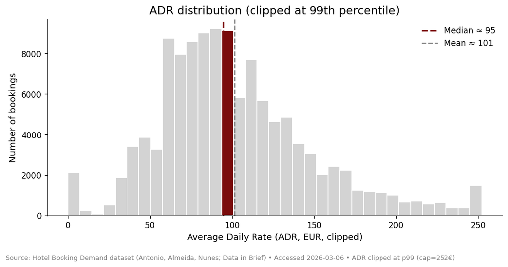

```
Median ADR (clipped): 94.59
Mean ADR (clipped): 101.46
```

```python
# --- Plot ---
fig, ax = plt.subplots(figsize=(8.8, 4.6))
counts, bins, patches = ax.hist(x, bins=35, color=MUTED, edgecolor="white")

# Highlight the bin containing the median
bin_idx = np.searchsorted(bins, median_adr) - 1
if 0 <= bin_idx < len(patches):
    patches[bin_idx].set_facecolor(HILITE)


ax.axvline(median_adr, color=HILITE, linestyle="--", linewidth=2, label=f"Median ≈ {median_adr:.0f}")
ax.axvline(mean_adr, color=TEXT_GRAY, linestyle="--", linewidth=1.5, label=f"Mean ≈ {mean_adr:.0f}")

ax.set_title("ADR distribution (clipped at 99th percentile)")
ax.set_xlabel("Average Daily Rate (ADR, EUR, clipped)")
ax.set_ylabel("Number of bookings")

ax.spines["top"].set_visible(False)
ax.spines["right"].set_visible(False)
ax.legend(frameon=False, loc="upper right")

fig.text(0.01, 0.01,
         f"Source: {SOURCE_NAME} • Accessed {ACCESS_DATE} • ADR clipped at p99 (cap={adr_cap:.0f}€)",
         ha="left", va="bottom", fontsize=8, color=TEXT_GRAY)

fig.tight_layout(rect=(0, 0.05, 1, 1))
plt.show()

print("Median ADR (clipped):", round(median_adr, 2))
print("Mean ADR (clipped):", round(mean_adr, 2))
```

### What the client should take from this chart

For the **revenue manager**, this chart shows that most bookings sit in a **middle ADR range**. The **median ADR is about €95**, while the **mean is about €101**.

In simple terms, the hotel’s usual price is closer to the middle of the distribution. Statistically, the **mean is higher than the median**, which suggests that a smaller number of expensive bookings are pulling the average up.

What the audience should do next is use this typical ADR band as the starting point for normal pricing, and treat the high-end outliers separately.

### Design choices for this chart

- **Understand the context:** This chart is for the revenue manager, who needs to see the hotel’s normal price range before making pricing decisions.
- **Choose an appropriate display:** I used a histogram because it shows where most bookings are concentrated across the ADR distribution.
- **Eliminate clutter:** I clipped ADR at the 99th percentile and removed extra chart borders so outliers would not dominate the view.
- **Draw attention:** I highlighted the bin around the median and added median and mean reference lines to show the center clearly.
- **Think like a designer:** I used one focus color and kept the rest of the bars muted so the eye goes first to the typical ADR band.
- **Tell a story:** The main message is that normal pricing should be based on the middle of the distribution, not on a few expensive bookings.

## Insight 2 — City and Resort hotels have clearly different price levels

**Audience:** Revenue manager / pricing team

**Business question:** Should City and Resort hotels use the same pricing baseline?

**Why this matters:** If the two hotel types usually sell at different ADR levels, one shared benchmark can hide real differences.

**Recommendation direction:** Use separate ADR baselines for City and Resort hotels.

```python
# Insight 2: City and Resort hotels have clearly different price levels

adr_col = "adr"
hotel_col = "hotel"

# --- Prepare data ---
g = df.dropna(subset=[adr_col, hotel_col]).copy()
g["hotel_type"] = g[hotel_col].replace({"City Hotel": "City", "Resort Hotel": "Resort"})

cap = g[adr_col].quantile(0.99)
g["adr_clip"] = g[adr_col].clip(upper=cap)
```

```python
order = ["City", "Resort"]
vals = [g.loc[g["hotel_type"] == k, "adr_clip"].values for k in order]

stats = {}
for k in order:
    s = g.loc[g["hotel_type"] == k, "adr_clip"]
    stats[k] = {
        "n": int(s.shape[0]),
        "median": float(np.median(s)),
        "q1": float(np.quantile(s, 0.25)),
        "q3": float(np.quantile(s, 0.75)),
    }

city_med = stats["City"]["median"]
res_med  = stats["Resort"]["median"]
delta = city_med - res_med
pct = (delta / res_med) * 100 if res_med else np.nan
```

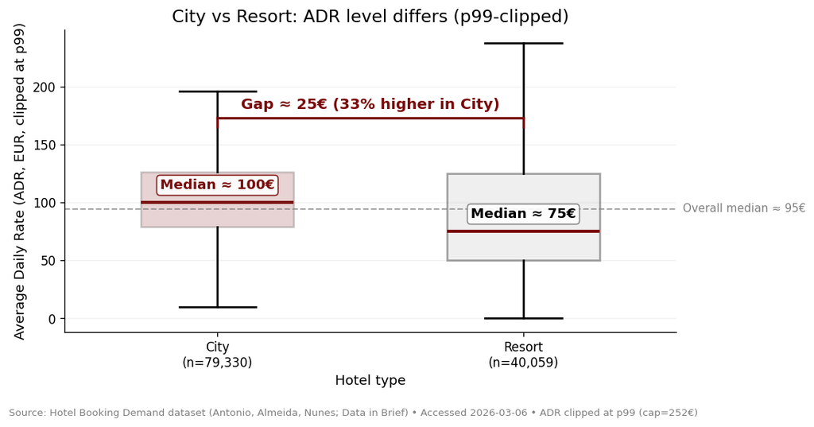

```python
# --- Plot ---
fig, ax = plt.subplots(figsize=(9.2, 4.8))

bp = ax.boxplot(
    vals,
    labels=[f"{k}\n(n={stats[k]['n']:,})" for k in order],
    widths=0.5,
    patch_artist=True,
    showfliers=False,
    medianprops=dict(color=HILITE, linewidth=2.5),
    boxprops=dict(linewidth=1.6, color="black"),
    whiskerprops=dict(linewidth=1.6, color="black"),
    capprops=dict(linewidth=1.6, color="black"),
)

# Fill colors (City highlighted, Resort muted)
fills = [(HILITE, 0.18), ("lightgray", 0.35)]
for patch, (c, a) in zip(bp["boxes"], fills):
    patch.set_facecolor(c)
    patch.set_alpha(a)

# Styling
ax.grid(axis="y", alpha=0.18)
ax.spines["top"].set_visible(False)
ax.spines["right"].set_visible(False)

ax.set_title("City vs Resort: ADR level differs (p99-clipped)")
ax.set_ylabel("Average Daily Rate (ADR, EUR, clipped at p99)")
ax.set_xlabel("Hotel type")

# --- Smart spacing helpers ---
ymin, ymax = ax.get_ylim()
yr = ymax - ymin
label_off = yr * 0.035

# Median labels
ax.text(
    1, city_med + label_off,
    f"Median ≈ {city_med:.0f}€",
    ha="center", va="bottom",
    fontsize=11, fontweight="bold", color=HILITE,
    bbox=dict(boxstyle="round,pad=0.25", fc="white", ec=HILITE, alpha=0.9)
)
ax.text(
    2, res_med + label_off,
    f"Median ≈ {res_med:.0f}€",
    ha="center", va="bottom",
    fontsize=11, fontweight="bold", color="black",
    bbox=dict(boxstyle="round,pad=0.25", fc="white", ec="gray", alpha=0.9)
)

# --- Gap bracket ---
y_bracket = max(stats["City"]["q3"], stats["Resort"]["q3"]) + yr * 0.18
tick = yr * 0.03

# horizontal bracket line
ax.plot([1, 2], [y_bracket, y_bracket], color=HILITE, linewidth=2)
# small vertical ticks down
ax.plot([1, 1], [y_bracket, y_bracket - tick], color=HILITE, linewidth=2)
ax.plot([2, 2], [y_bracket, y_bracket - tick], color=HILITE, linewidth=2)

ax.text(
    1.5, y_bracket + tick * 0.7,
    f"Gap ≈ {delta:.0f}€ ({pct:.0f}% higher in City)",
    ha="center", va="bottom",
    fontsize=12, fontweight="bold", color=HILITE
)

# Overall median reference line
overall_ref = np.median(g["adr_clip"].values)
ax.axhline(overall_ref, linestyle="--", linewidth=1.2, color="gray", alpha=0.7)
ax.text(
    1.01, overall_ref, f"Overall median ≈ {overall_ref:.0f}€",
    transform=ax.get_yaxis_transform(),  # x in axes coords, y in data coords
    ha="left", va="center", fontsize=9, color="gray"
)

# Give headroom for bracket
ax.set_ylim(ymin, max(ymax, y_bracket + yr * 0.12))

# Footnote
fig.text(
    0.01, 0.01,
    f"Source: {SOURCE_NAME} • Accessed {ACCESS_DATE} • ADR clipped at p99 (cap={cap:.0f}€)",
    ha="left", va="bottom", fontsize=8, color="gray"
)

fig.tight_layout(rect=(0, 0.05, 1, 1))
plt.show()
```

### What the client should take from this chart

For the **revenue manager**, this chart shows that City and Resort hotels do not sit at the same normal price level. The **median ADR for City is about €100**, while the **median ADR for Resort is about €75**, so City is roughly **€25 higher**.

The main point is simple: this difference appears in the middle of the distribution, so it reflects a real gap between the two hotel types.

What the audience should do next is use separate pricing baselines for City and Resort hotels, instead of one overall ADR benchmark.

### Design choices for this chart

- **Understand the context:** This chart is for the pricing team, which needs to compare the normal ADR level of City and Resort hotels.
- **Choose an appropriate display:** I used a box plot because it compares distribution, median, and spread side by side.
- **Eliminate clutter:** I hid outliers and used direct labels instead of adding too many extra elements.
- **Draw attention:** I highlighted the City box, labeled both medians, and added a bracket showing the size of the gap.
- **Think like a designer:** I used muted gray for Resort and deep red for City so the comparison stays clear without too many colors.
- **Tell a story:** The main message is that City and Resort hotels do not share the same pricing baseline.

## Insight 3 — Resort hotels have a much stronger summer price peak than City hotels

**Audience:** Revenue manager / commercial planning team

**Business question:** Do City and Resort hotels follow the same pricing pattern through the year?

**Why this matters:** If Resort ADR rises sharply in peak season while City ADR stays more stable, one shared pricing calendar will miss an important difference.

**Recommendation direction:** Use different seasonal pricing plans for City and Resort hotels.

```python
# Insight 3: Resort hotels have a much stronger summer price peak than City hotels
g = df.dropna(subset=["arrival_month", "hotel_type", "adr_clip"]).copy()

monthly = (g.groupby(["hotel_type", "arrival_month"])["adr_clip"]
             .median()
             .reset_index())

# Prepare series
m_city = monthly[monthly["hotel_type"]=="City"].set_index("arrival_month")["adr_clip"].reindex(range(1,13))
m_resort = monthly[monthly["hotel_type"]=="Resort"].set_index("arrival_month")["adr_clip"].reindex(range(1,13))

months = np.arange(1, 13)
month_labels = ["Jan","Feb","Mar","Apr","May","Jun","Jul","Aug","Sep","Oct","Nov","Dec"]
```

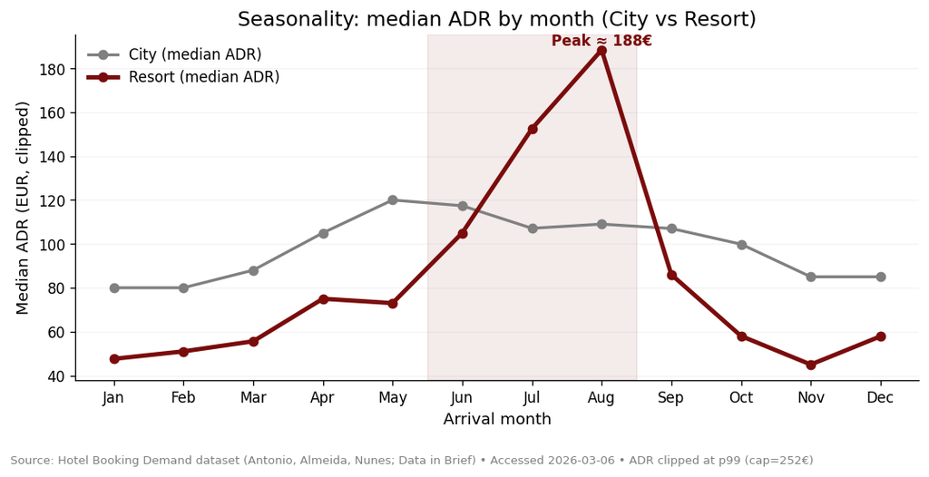

```python
# --- Plot ---
fig, ax = plt.subplots(figsize=(9.0, 4.6))

ax.plot(months, m_city.values, marker="o", color=TEXT_GRAY, linewidth=2, label="City (median ADR)")
ax.plot(months, m_resort.values, marker="o", color=HILITE, linewidth=3, label="Resort (median ADR)")

# Highlight typical resort peak window (Jun–Aug)
ax.axvspan(6-0.5, 8+0.5, color=HILITE, alpha=0.08)

ax.set_xticks(months)
ax.set_xticklabels(month_labels)

ax.set_title("Seasonality: median ADR by month (City vs Resort)")
ax.set_xlabel("Arrival month")
ax.set_ylabel("Median ADR (EUR, clipped)")

ax.spines["top"].set_visible(False)
ax.spines["right"].set_visible(False)
ax.grid(axis="y", alpha=0.15)
ax.legend(frameon=False, loc="upper left")

# Annotate resort peak month
peak_m = int(np.nanargmax(m_resort.values) + 1)
peak_v = float(m_resort.loc[peak_m])
ax.text(peak_m, peak_v + 2, f"Peak ≈ {peak_v:.0f}€", color=HILITE, ha="center", fontweight="bold")

fig.text(0.01, 0.01,
         f"Source: {SOURCE_NAME} • Accessed {ACCESS_DATE} • ADR clipped at p99 (cap={adr_cap:.0f}€)",
         ha="left", va="bottom", fontsize=8, color=TEXT_GRAY)

fig.tight_layout(rect=(0, 0.06, 1, 1))
plt.show()
```

### What the client should take from this chart

For the **revenue manager**, this chart shows a clear difference between the two hotel types. **Resort ADR rises sharply in summer and peaks at about €188 in August**, while **City ADR stays much more stable** across the year.

The main point is simple: City and Resort hotels should not be managed with the same seasonal pricing logic.

What the audience should do next is use a stronger peak-season strategy for Resorts and a more balanced year-round strategy for Cities.

### Design choices for this chart

- **Understand the context:** This chart is for the revenue manager, who needs to know whether City and Resort hotels should follow the same seasonal pricing plan.
- **Choose an appropriate display:** I used a line chart because the question is about how ADR changes month by month over time.
- **Eliminate clutter:** I kept only two lines, removed unnecessary borders, and used a light grid to support reading without distraction.
- **Draw attention:** I highlighted the summer peak window and labeled the Resort peak month directly.
- **Think like a designer:** I used gray for City and deep red for Resort so the more seasonal series stands out immediately.
- **Tell a story:** The main message is that Resort pricing is much more seasonal, so it needs a stronger peak-season strategy.

## Insight 4 — The further ahead a guest books, the more likely the booking is to cancel

**Audience:** Revenue manager / booking policy team

**Business question:** When does lead time become a real cancellation risk, and does that risk differ between City and Resort hotels?

**Why this matters:** Bookings made far in advance are less secure because guests have more time to change plans. If that risk is also different by hotel type, the hotel should not use one flat booking policy for all future bookings.

**Recommendation direction:** Treat long-lead bookings more carefully, especially for **City hotels**. Use stronger cancellation rules, deposits, earlier reconfirmation, or more cautious overbooking where risk is highest.

### Insight 4A: Cancellation risk rises as lead time gets longer

```python
g = df.dropna(subset=["lead_time_bin", "is_canceled"]).copy()

rate = g.groupby("lead_time_bin")["is_canceled"].mean()
n = g.groupby("lead_time_bin")["is_canceled"].size()

x = np.arange(len(rate.index))
y = rate.values * 100
```

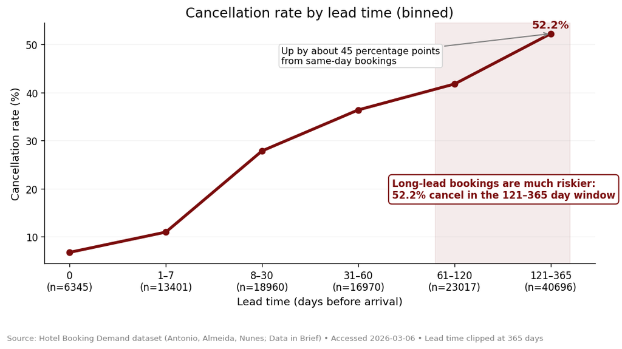

```python
# --- Plot ---
fig, ax = plt.subplots(figsize=(9.2, 5.0))

# Base line
ax.plot(x, y, marker="o", linewidth=3, color=HILITE, zorder=3)

# Highlight long lead-time zone (61+)
ax.axvspan(4 - 0.2, len(x) - 0.8, color=HILITE, alpha=0.08, zorder=0)

# Axes
ax.set_xticks(x)
ax.set_xticklabels([f"{lab}\n(n={int(n.loc[lab])})" for lab in rate.index])

ax.set_title("Cancellation rate by lead time (binned)")
ax.set_xlabel("Lead time (days before arrival)")
ax.set_ylabel("Cancellation rate (%)")

ax.spines["top"].set_visible(False)
ax.spines["right"].set_visible(False)
ax.grid(axis="y", alpha=0.15)

# Label highest-risk point
worst_i = int(np.argmax(y))
ax.text(
    worst_i,
    y[worst_i] + 1.2,
    f"{y[worst_i]:.1f}%",
    color=HILITE,
    ha="center",
    fontweight="bold",
    fontsize=11
)

# Add a callout for the main message
ax.text(
    3.35, 18,
    f"Long-lead bookings are much riskier:\n"
    f"{y[-1]:.1f}% cancel in the 121–365 day window",
    fontsize=10,
    color=HILITE,
    fontweight="bold",
    bbox=dict(
        boxstyle="round,pad=0.35",
        facecolor="white",
        edgecolor=HILITE,
        linewidth=1.2,
        alpha=0.95
    )
)

# Add a second callout showing how much higher risk becomes
delta = y[-1] - y[0]
ax.annotate(
    f"Up by about {delta:.0f} percentage points\nfrom same-day bookings",
    xy=(5, y[-1]),
    xytext=(2.2, 46),
    textcoords="data",
    fontsize=9.5,
    color="black",
    arrowprops=dict(arrowstyle="->", color=TEXT_GRAY, lw=1.2),
    bbox=dict(boxstyle="round,pad=0.25", facecolor="white", edgecolor="lightgray", alpha=0.9)
)

fig.text(
    0.01, 0.01,
    f"Source: {SOURCE_NAME} • Accessed {ACCESS_DATE} • Lead time clipped at 365 days",
    ha="left", va="bottom", fontsize=8, color=TEXT_GRAY
)

fig.tight_layout(rect=(0, 0.08, 1, 1))
plt.show()
```

### Design choices for this chart (4A)

- **Understand the context:** This chart is for the booking policy team, which needs to know when lead time becomes a serious cancellation risk.
- **Choose an appropriate display:** I used a line chart because it shows the overall trend in cancellation risk across booking windows.
- **Eliminate clutter:** I grouped lead time into business-friendly bins and kept the chart focused on one clear pattern.
- **Draw attention:** I highlighted the long-lead zone and added callouts to the riskiest point and the increase from same-day bookings.
- **Think like a designer:** I used one strong color for the line and muted background elements so the trend is easy to follow.
- **Tell a story:** The main message is that bookings made far in advance are much less reliable than short-window bookings.

### Insight 4B: Dumbbell chart — City vs Resort cancellation risk by lead-time bin

```python
lead_order = ["0", "1–7", "8–30", "31–60", "61–120", "121–365"]

g_db = df.dropna(subset=["hotel_type", "lead_time_bin", "is_canceled"]).copy()
g_db = g_db[g_db["hotel_type"].isin(["City", "Resort"])].copy()

g_db["lead_time_bin"] = pd.Categorical(
    g_db["lead_time_bin"].astype(str),
    categories=lead_order,
    ordered=True
)
```

```python
# Cancellation rate (%) and sample size
summ = (
    g_db.groupby(["lead_time_bin", "hotel_type"])["is_canceled"]
    .agg(["mean", "size"])
    .reset_index()
)

rate = (
    summ.pivot(index="lead_time_bin", columns="hotel_type", values="mean")
    .reindex(lead_order)
    .mul(100)
)

rate["gap"] = rate["City"] - rate["Resort"]
```

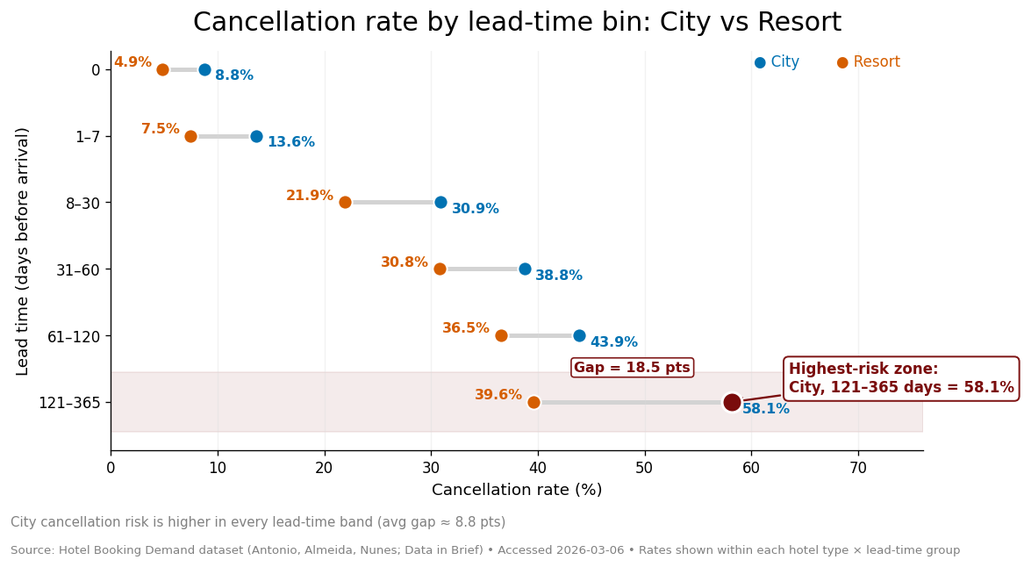

```python
# Plot positions
y = np.arange(len(lead_order))

fig, ax = plt.subplots(figsize=(9.8, 5.8))

# --- Main title ---
ax.set_title("Cancellation rate by lead-time bin: City vs Resort", pad=14, fontsize=18)

# --- Small color key ---
fig.text(0.73, 0.82, "● City", color=CITY, fontsize=10, va="center")
fig.text(0.81, 0.82, "● Resort", color=RESORT, fontsize=10, va="center")

# Highlight longest booking window
worst_bin = rate["City"].idxmax()
worst_y = lead_order.index(worst_bin)
ax.axhspan(worst_y - 0.45, worst_y + 0.45, color=HILITE, alpha=0.08, zorder=0)

# Dumbbell connectors
for i, b in enumerate(lead_order):
    x1 = rate.loc[b, "Resort"]
    x2 = rate.loc[b, "City"]
    ax.plot([x1, x2], [i, i], color="lightgray", linewidth=3, zorder=1)

# Points
ax.scatter(
    rate["Resort"], y,
    s=95, color=RESORT, edgecolor="white", linewidth=1.2,
    zorder=3
)
ax.scatter(
    rate["City"], y,
    s=95, color=CITY, edgecolor="white", linewidth=1.2,
    zorder=3
)

# Highlight on highest-risk point
ax.scatter(
    rate.loc[worst_bin, "City"], worst_y,
    s=190, color=HILITE, edgecolor="white", linewidth=1.8, zorder=4
)

# Value labels
for i, b in enumerate(lead_order):
    city_val = rate.loc[b, "City"]
    resort_val = rate.loc[b, "Resort"]

    ax.text(
        city_val + 1.0, i + 0.10,
        f"{city_val:.1f}%",
        color=CITY, fontsize=9.5, fontweight="bold",
        ha="left", va="center"
    )
    ax.text(
        resort_val - 1.0, i - 0.10,
        f"{resort_val:.1f}%",
        color=RESORT, fontsize=9.5, fontweight="bold",
        ha="right", va="center"
    )

# Gap label on most important row
last_gap = rate.loc[worst_bin, "gap"]
mid_x = (rate.loc[worst_bin, "City"] + rate.loc[worst_bin, "Resort"]) / 2
ax.text(
    mid_x, worst_y - 0.42,
    f"Gap = {last_gap:.1f} pts",
    ha="center", va="bottom",
    fontsize=9.5, fontweight="bold", color=HILITE,
    bbox=dict(
        boxstyle="round,pad=0.22",
        facecolor="white",
        edgecolor=HILITE,
        alpha=0.95
    )
)

# Main callout on the right
ax.annotate(
    f"Highest-risk zone:\nCity, {worst_bin} days = {rate.loc[worst_bin, 'City']:.1f}%",
    xy=(rate.loc[worst_bin, "City"], worst_y),
    xytext=(63.5, worst_y - 0.35),
    textcoords="data",
    ha="left", va="center",
    fontsize=10,
    fontweight="bold",
    color=HILITE,
    arrowprops=dict(arrowstyle="->", color=HILITE, lw=1.4),
    bbox=dict(
        boxstyle="round,pad=0.35",
        facecolor="white",
        edgecolor=HILITE,
        linewidth=1.2,
        alpha=0.96
    )
)

# Axes and styling
ax.set_yticks(y)
ax.set_yticklabels(lead_order)
ax.invert_yaxis()
ax.set_xlabel("Cancellation rate (%)")
ax.set_ylabel("Lead time (days before arrival)")

ax.spines["top"].set_visible(False)
ax.spines["right"].set_visible(False)
ax.grid(axis="x", color=GRID, alpha=0.35)

# Space on right for callout
xmax = max(rate["City"].max(), rate["Resort"].max())
ax.set_xlim(0, xmax + 18)

avg_gap = rate["gap"].mean()
fig.text(
    0.01, 0.055,
    f"City cancellation risk is higher in every lead-time band (avg gap ≈ {avg_gap:.1f} pts)",
    ha="left", va="bottom",
    fontsize=9, color=TEXT_GRAY
)

# Source
fig.text(
    0.01, 0.01,
    f"Source: {SOURCE_NAME} • Accessed {ACCESS_DATE} • "
    f"Rates shown within each hotel type × lead-time group",
    ha="left", va="bottom", fontsize=8, color=TEXT_GRAY
)

# Leave room at top and bottom
fig.tight_layout(rect=(0, 0.08, 1, 0.93))
plt.show()
```

### Design choices for this chart (4B)

- **Understand the context:** This chart is for the revenue manager, who needs to compare cancellation risk between City and Resort hotels across the same booking windows.
- **Choose an appropriate display:** I used a dumbbell chart because it makes the gap between two groups easy to compare in each lead-time bin.
- **Eliminate clutter:** I removed a full legend box, simplified the labels, and used one connector line per row to keep the comparison clean.
- **Draw attention:** I highlighted the longest lead-time band and added a callout to the highest-risk City point.
- **Think like a designer:** I used consistent blue and orange group colors, plus one red highlight for the most important risk point.
- **Tell a story:** The main message is that City bookings are riskier than Resort bookings in every lead-time band.

### What the client should take from these charts (4A + 4B)

For the **revenue manager**, these two charts show two connected points. First, **cancellation risk rises as lead time gets longer**. Second, that risk is **consistently higher for City bookings than for Resort bookings** across every lead-time band.

The line chart shows the overall pattern clearly: bookings made far in advance are much less reliable, with the **121–365 day** group showing the highest cancellation risk. The dumbbell chart adds the comparison view and shows that **City bookings are the riskier side at every stage of the booking window**, with the biggest gap also appearing in the longest lead-time group.

The main point is simple: the hotel should not treat all future bookings as equally secure, and it should not manage **City and Resort** bookings with the same cancellation-risk logic.

What the audience should do next is apply **stronger protection to long-lead bookings first**, especially for **City bookings**, using tighter cancellation rules, deposit requirements, earlier reconfirmation, or more cautious overbooking where needed.

## Insight 5 — The best segments combine higher price with lower cancellation

**Audience:** Revenue manager / distribution manager

**Business question:** Which segments bring a good mix of price and reliability?

**Why this matters:** A segment is not attractive just because it has a high ADR. If it also cancels a lot, it may be less valuable than it first looks.

**Recommendation direction:** Give more attention to segments with **higher ADR and lower cancellation**. Be more careful with segments that bring volume but cancel often.

```python
# Insight 5: The best segments combine higher price with lower cancellation
g = df.dropna(subset=["market_segment", "adr_clip", "is_canceled"]).copy()

seg = (g.groupby("market_segment")
         .agg(adr=("adr_clip", "median"),
              cancel=("is_canceled", "mean"),
              n=("is_canceled", "size"))
         .sort_values("n", ascending=False))

# Keep top segments to avoid clutter
seg = seg.head(8).copy()
```

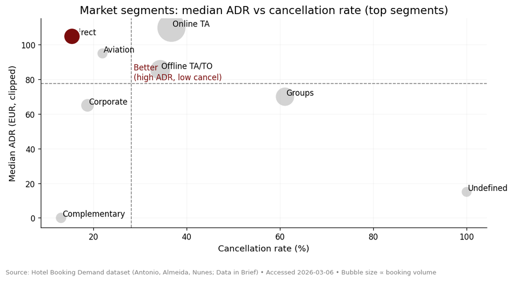

```
Highlighted segment: Direct
```

```python
# --- Plot ---
fig, ax = plt.subplots(figsize=(9.2, 5.0))

# Scatter points
sizes = (seg["n"] / seg["n"].max()) * 1200 + 200  # readable scale
ax.scatter(seg["cancel"]*100, seg["adr"], s=sizes, color=MUTED, edgecolor="white", linewidth=1.5)

# Label points
for name, row in seg.iterrows():
    ax.text(row["cancel"]*100 + 0.25, row["adr"] + 0.8, name, fontsize=10)

# Highlight the "best" segment by a simple score: high ADR, low cancel
score = (seg["adr"] - seg["adr"].median()) - 0.8*(seg["cancel"] - seg["cancel"].median())*100
best = score.idxmax()
ax.scatter(seg.loc[best, "cancel"]*100, seg.loc[best, "adr"],
           s=sizes.loc[best], color=HILITE, edgecolor="white", linewidth=2.0, zorder=3)

# Reference lines (medians)
ax.axvline(seg["cancel"].median()*100, color=TEXT_GRAY, linestyle="--", linewidth=1)
ax.axhline(seg["adr"].median(), color=TEXT_GRAY, linestyle="--", linewidth=1)

ax.set_title("Market segments: median ADR vs cancellation rate (top segments)")
ax.set_xlabel("Cancellation rate (%)")
ax.set_ylabel("Median ADR (EUR, clipped)")

ax.spines["top"].set_visible(False)
ax.spines["right"].set_visible(False)
ax.grid(alpha=0.12)

ax.text(seg["cancel"].median()*100 + 0.5, seg["adr"].median() + 2,
        "Better \n(high ADR, low cancel)", color=HILITE, fontsize=10)

fig.text(0.01, 0.01,
         f"Source: {SOURCE_NAME} • Accessed {ACCESS_DATE} • Bubble size ∝ booking volume",
         ha="left", va="bottom", fontsize=8, color=TEXT_GRAY)

fig.tight_layout(rect=(0, 0.06, 1, 1))
plt.show()

print("Highlighted segment:", best)
```

### What the client should take from this chart

For the **revenue manager**, this chart shows that not all segments are equally valuable. The highlighted **Direct** segment stands out because it combines **high ADR** with **low cancellation**, which makes it one of the strongest segments in the chart.

The main point is simple: volume alone is not enough. Some larger segments, like **Online TA** or **Groups**, may still bring many bookings, but they also come with higher cancellation risk.

What the audience should do next is focus more on segments that are both **profitable and reliable**, and manage weaker segments more carefully.

### Design choices for this chart

- **Understand the context:** This chart is for the distribution manager, who needs to judge segment quality by both price and reliability.
- **Choose an appropriate display:** I used a bubble scatter because it shows ADR, cancellation rate, and booking volume in one view.
- **Eliminate clutter:** I limited the chart to the top segments and used direct labels instead of adding extra legends or notes.
- **Draw attention:** I highlighted the strongest segment and added median reference lines to separate stronger and weaker areas.
- **Think like a designer:** I kept most bubbles muted and used one focus color for the highlighted segment so the eye goes to the best opportunity first.
- **Tell a story:** The main message is that volume alone is not enough; the best segments combine good price with lower cancellation.

## Insight 6 — Some room types are reassigned much more often than others

**Audience:** Operations manager / inventory control team

**Business question:** Which room types are most often assigned differently from what the guest originally booked?

**Why this matters:** If some room types are reassigned too often, that can signal inventory pressure or room-allocation problems. It can also affect the guest experience.

**Recommendation direction:** Track mismatch rates by room type and investigate the highest-risk categories first, especially when the booking volume is also high.

```python
# Insight 6: Some room types are reassigned much more often than others
g = df.dropna(subset=["reserved_room_type", "assigned_room_type", "adr_clip"]).copy()
g["mismatch"] = (g["reserved_room_type"] != g["assigned_room_type"]).astype(int)

room = (g.groupby("reserved_room_type")
          .agg(mismatch_rate=("mismatch","mean"),
               adr=("adr_clip","median"),
               n=("mismatch","size"))
          .sort_values("n", ascending=False)
          .head(8)
          .sort_values("mismatch_rate", ascending=True))
```

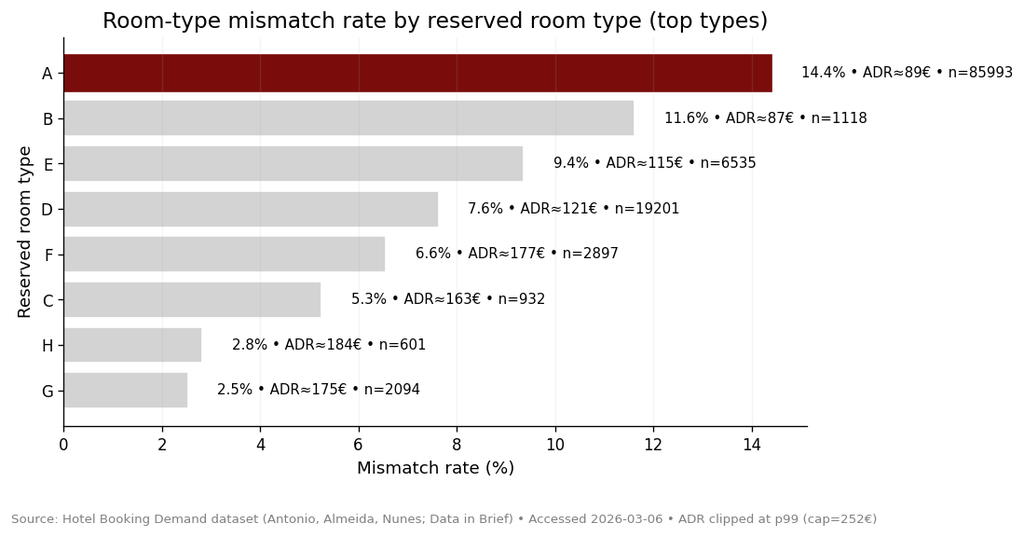

```
Highest mismatch type: A
```

```python
# --- Plot ---
fig, ax = plt.subplots(figsize=(9.2, 4.8))

bars = ax.barh(room.index, room["mismatch_rate"]*100, color=MUTED, edgecolor="white")

# Highlight worst mismatch type
worst = room["mismatch_rate"].idxmax()
bars[list(room.index).index(worst)].set_color(HILITE)

ax.set_title("Room-type mismatch rate by reserved room type (top types)")
ax.set_xlabel("Mismatch rate (%)")
ax.set_ylabel("Reserved room type")

for i, (rt, row) in enumerate(room.iterrows()):
    ax.text(row["mismatch_rate"]*100 + 0.6, i,
            f"{row['mismatch_rate']*100:.1f}% • ADR≈{row['adr']:.0f}€ • n={int(row['n'])}",
            va="center", fontsize=9)

ax.spines["top"].set_visible(False)
ax.spines["right"].set_visible(False)
ax.grid(axis="x", alpha=0.15)

fig.text(0.01, 0.01,
         f"Source: {SOURCE_NAME} • Accessed {ACCESS_DATE} • ADR clipped at p99 (cap={adr_cap:.0f}€)",
         ha="left", va="bottom", fontsize=8, color=TEXT_GRAY)

fig.tight_layout(rect=(0, 0.07, 1, 1))
plt.show()

print("Highest mismatch type:", worst)
```

### What the client should take from this chart

For the **operations manager**, this chart shows that mismatch is not spread evenly across room types. **Room type A** stands out the most, with the **highest mismatch rate** and also the **largest booking volume**, so it creates the biggest operational concern.

The main point is simple: some room types create much more reassignment pressure than others.

What the audience should do next is focus first on the room types where mismatch is both **frequent** and **high-volume**. In this chart, that means starting with **type A**.

### Design choices for this chart

- **Understand the context:** This chart is for the operations team, which needs to identify where room reassignment pressure is highest.
- **Choose an appropriate display:** I used a horizontal bar chart because it is the clearest way to rank room types by mismatch rate.
- **Eliminate clutter:** I showed only the top room types and removed unnecessary chart borders.
- **Draw attention:** I highlighted the worst room type and added direct labels with mismatch rate, ADR, and volume.
- **Think like a designer:** I sorted the bars by mismatch rate so the audience can understand the ranking immediately.
- **Tell a story:** The main message is that a few room types create much more operational pressure than the rest.

## Insight 7 — City and Resort hotels follow different pricing patterns before arrival

**Audience:** Revenue manager / pricing team

**Business question:** Do City and Resort hotels show different price patterns before arrival?

**Why this matters:** If one hotel type keeps a higher ADR through much of the booking window, the revenue team should not manage both hotels in the same way.

**Recommendation direction:** Use different timing for pricing and inventory decisions by hotel type, especially in the middle booking window where the gap is clearest.

```python
# Insight 7: City and Resort hotels do not behave the same across the booking window
g_plot = df.dropna(subset=["lead_time", "adr_clip", "hotel_type"]).copy()
g_plot["lead_time"] = g_plot["lead_time"].clip(upper=365)

# light sampling to reduce overplotting
if len(g_plot) > 30000:
    g_plot = g_plot.sample(30000, random_state=42)

is_city = g_plot["hotel_type"].eq("City")
is_resort = g_plot["hotel_type"].eq("Resort")

# 30-day bins for business-readable trend lines
g_plot["lead_bin"] = (g_plot["lead_time"] // 30) * 30

trend = (
    g_plot.groupby(["hotel_type", "lead_bin"])["adr_clip"]
    .median()
    .reset_index()
)
trend["lead_mid"] = trend["lead_bin"] + 15

city_trend = trend[trend["hotel_type"] == "City"].copy()
resort_trend = trend[trend["hotel_type"] == "Resort"].copy()

# Callout window used in the annotation
window = g_plot["lead_time"].between(60, 180)
city_med = g_plot.loc[window & is_city, "adr_clip"].median()
resort_med = g_plot.loc[window & is_resort, "adr_clip"].median()
```

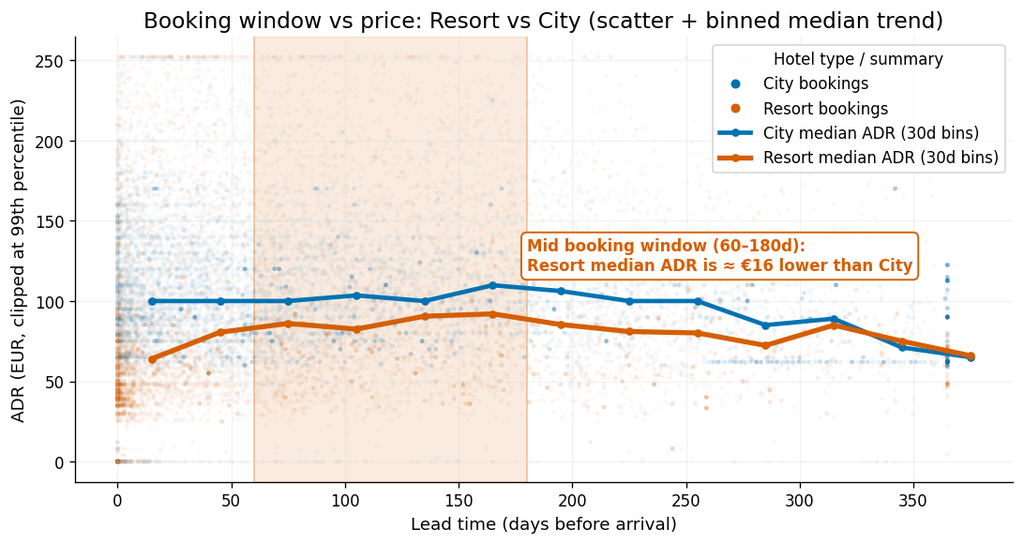

```python
# --- Plot ---
fig, ax = plt.subplots(figsize=(9.2, 5.2))

# --- Light sampling to reduce visual noise ---
city_scatter = g_plot.loc[is_city, ["lead_time", "adr_clip"]].copy()
resort_scatter = g_plot.loc[is_resort, ["lead_time", "adr_clip"]].copy()

city_scatter = city_scatter.sample(min(len(city_scatter), 8000), random_state=42)
resort_scatter = resort_scatter.sample(min(len(resort_scatter), 8000), random_state=42)

# Highlight the mid booking window
ax.axvspan(60, 180, color=RESORT, alpha=0.12, zorder=0)
ax.axvline(60, color=RESORT, alpha=0.2, linewidth=1.2, zorder=0)
ax.axvline(180, color=RESORT, alpha=0.2, linewidth=1.2, zorder=0)

# Scatter points
ax.scatter(
    city_scatter["lead_time"],
    city_scatter["adr_clip"],
    s=8, alpha=0.04, color=CITY, edgecolors="none",
    label="City bookings",
    zorder=1
)

ax.scatter(
    resort_scatter["lead_time"],
    resort_scatter["adr_clip"],
    s=8, alpha=0.04, color=RESORT, edgecolors="none",
    label="Resort bookings",
    zorder=1
)

# Trend lines
ax.plot(
    city_trend["lead_mid"],
    city_trend["adr_clip"],
    marker="o", markersize=4.2, linewidth=2.8, color=CITY,
    label="City median ADR (30d bins)",
    zorder=3
)

ax.plot(
    resort_trend["lead_mid"],
    resort_trend["adr_clip"],
    marker="o", markersize=4.2, linewidth=3.2, color=RESORT,
    label="Resort median ADR (30d bins)",
    zorder=4
)

# Callout text
if pd.notna(city_med) and pd.notna(resort_med):
    gap = resort_med - city_med
    gap_abs = abs(gap)

    ax.text(
        180, 128,
        f"Mid booking window (60–180d):\nResort median ADR is ≈ €{gap_abs:.0f} lower than City",
        ha="left", va="center",
        fontsize=10, fontweight="bold", color=RESORT,
        bbox=dict(
            boxstyle="round,pad=0.35",
            facecolor="white",
            edgecolor=RESORT,
            linewidth=1.2,
            alpha=0.96
        ),
        zorder=5
    )

# Titles + axis labels
ax.set_title("Booking window vs price: Resort vs City (scatter + binned median trend)")
ax.set_xlabel("Lead time (days before arrival)")
ax.set_ylabel("ADR (EUR, clipped at 99th percentile)")

# Styling
ax.spines["top"].set_visible(False)
ax.spines["right"].set_visible(False)
ax.grid(axis="both", color=GRID, alpha=0.35)
legend_handles = [
    Line2D([0], [0], marker='o', linestyle='None',
           markerfacecolor=CITY, markeredgecolor='none',
           markersize=6, label='City bookings'),
    Line2D([0], [0], marker='o', linestyle='None',
           markerfacecolor=RESORT, markeredgecolor='none',
           markersize=6, label='Resort bookings'),
    Line2D([0], [0], color=CITY, marker='o',
           linewidth=2.8, markersize=4.2,
           label='City median ADR (30d bins)'),
    Line2D([0], [0], color=RESORT, marker='o',
           linewidth=3.2, markersize=4.2,
           label='Resort median ADR (30d bins)')
]

ax.legend(
    handles=legend_handles,
    loc="upper right",
    title="Hotel type / summary",
    frameon=True
)

fig.tight_layout(rect=(0, 0.05, 1, 1))
plt.show()
```

### What the client should take from this chart

For the **revenue manager**, this chart shows that **City bookings keep a higher median ADR than Resort bookings through much of the booking window**. The clearest gap appears in the highlighted **60–180 day** range, where **Resort median ADR is about €16 lower than City**.

The main point is simple: **City and Resort hotels should not use the same booking-window strategy**.

What the audience should do next is review pricing and inventory decisions separately for City and Resort hotels, especially in the **middle booking window**, where the price gap is easiest to see.

### Design choices for this chart

- **Understand the context:** This chart is for the pricing team, which needs to compare how ADR behaves across the booking window for City and Resort hotels.
- **Choose an appropriate display:** I used a scatter with binned median trend lines because it shows both the raw spread and the clearer business pattern.
- **Eliminate clutter:** I sampled the points, reduced opacity, and used 30-day bins so the chart stays readable.
- **Draw attention:** I highlighted the 60–180 day window and added a callout showing the size of the ADR gap.
- **Think like a designer:** I used transparent points and stronger trend lines so the audience sees the pattern before the noise.
- **Tell a story:** The main message is that City and Resort hotels should not use the same booking-window strategy.

## Insight 8 — Demand load changes over time and differs by hotel type

**Audience:** Operations manager / revenue manager

**Business question:** When is demand highest, and do City and Resort hotels follow the same pattern across the year?

**Why this matters:** Room-nights sold give a better picture of real demand than raw bookings, because they reflect both booking volume and length of stay. This helps the hotel see when staffing, inventory, and pricing pressure are highest.

**Recommendation direction:** Plan staffing, inventory, and pricing around the peak-demand months. Do not assume City and Resort hotels need the same operational plan at the same time.

```python
# Insight 8: Demand load changes over time and differs by hotel type
g = df[
    (df["is_canceled"] == 0) &
    df["arrival_date"].notna() &
    (df["stay_nights"] > 0)
].copy()

g["arrival_month_start"] = g["arrival_date"].dt.to_period("M").dt.to_timestamp()

monthly = (
    g.groupby(["arrival_month_start", "hotel_type"])["stay_nights"]
    .sum()
    .unstack(fill_value=0)
    .sort_index()
)

# Ensure both hotel types exist in stable order
for col in ["City", "Resort"]:
    if col not in monthly.columns:
        monthly[col] = 0
monthly = monthly[["City", "Resort"]]

x = np.arange(len(monthly.index))
labels = monthly.index.strftime("%b %Y")
```

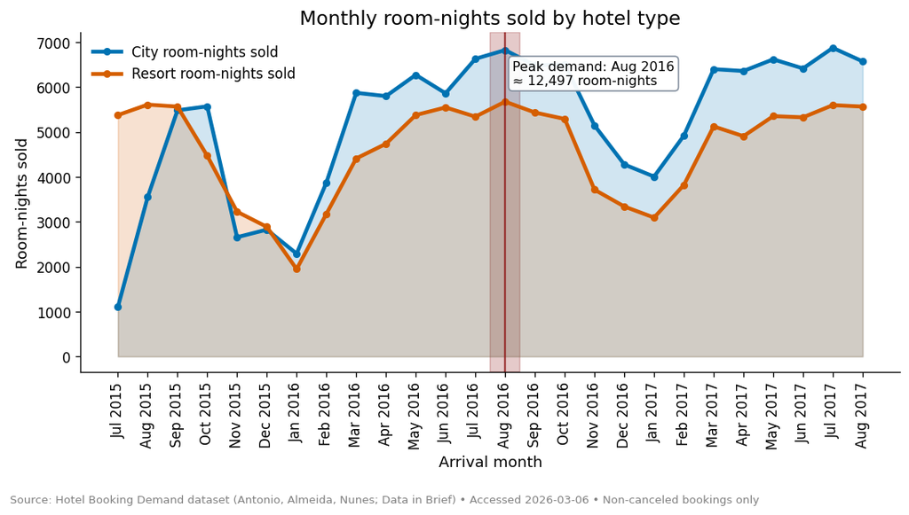

```python
# --- Plot ---
fig, ax = plt.subplots(figsize=(9.2, 5.2))

# Filled areas
ax.fill_between(x, monthly["City"].values, color=CITY, alpha=0.18, zorder=1)
ax.fill_between(x, monthly["Resort"].values, color=RESORT, alpha=0.18, zorder=1)

# Lines on top
ax.plot(
    x, monthly["City"].values,
    color=CITY, linewidth=2.8, marker="o", markersize=4.5,
    label="City room-nights sold"
)
ax.plot(
    x, monthly["Resort"].values,
    color=RESORT, linewidth=2.8, marker="o", markersize=4.5,
    label="Resort room-nights sold"
)

# Highlight overall peak month
total = monthly.sum(axis=1)
peak_idx = int(np.argmax(total.values))
peak_label = monthly.index[peak_idx].strftime("%b %Y")
peak_total = int(total.iloc[peak_idx])

# highlight band
ax.axvspan(
    peak_idx - 0.5, peak_idx + 0.5,
    color=RED_HIGHLIGHT, alpha=0.22, zorder=0
)
ax.axvline(
    peak_idx,
    color=RED_HIGHLIGHT, linewidth=1.4, alpha=0.75, zorder=2
)

ax.text(
    peak_idx + 0.25,
    max(monthly.max()) * 0.96,
    f"Peak demand: {peak_label}\n≈ {peak_total:,} room-nights",
    ha="left", va="top",
    fontsize=9.5, color="black",
    bbox=dict(
        boxstyle="round,pad=0.3",
        facecolor="white",
        edgecolor="#7E8A9A",
        linewidth=1.0,
        alpha=0.95
    )
)

ax.set_title("Monthly room-nights sold by hotel type")
ax.set_xlabel("Arrival month")
ax.set_ylabel("Room-nights sold")

ax.set_xticks(x)
ax.set_xticklabels(labels, rotation=90)

ax.spines["top"].set_visible(False)
ax.spines["right"].set_visible(False)
ax.grid(axis="y", color=GRID, alpha=0.35)
ax.legend(frameon=False, loc="upper left")

fig.text(
    0.01, 0.01,
    f"Source: {SOURCE_NAME} • Accessed {ACCESS_DATE} • Non-canceled bookings only",
    ha="left", va="bottom", fontsize=8, color=TEXT_GRAY
)

fig.tight_layout(rect=(0, 0.05, 1, 1))

plt.grid(False)
plt.show()
```

### What the client should take from this chart

For the **operations and revenue team**, this chart shows that demand is **not flat through the year** and that **City and Resort hotels do not peak in exactly the same way**. The busiest point is around **August 2016**, and City carries the heavier room-night load in much of the later period.

The main point is simple: the hotel should **plan around peak-demand months**, not use the same year-round staffing and inventory approach.

What the audience should do next is prepare earlier for the busiest months and treat **City and Resort hotels as related, but not identical, demand patterns**.

### Design choices for this chart

- **Understand the context:** This chart is for the operations and revenue team, which needs to know when demand pressure is highest.
- **Choose an appropriate display:** I used an area chart with lines because it shows demand load over time and makes peak periods easy to see.
- **Eliminate clutter:** I kept the chart to two series, removed extra borders, and used a light grid only on the y-axis.
- **Draw attention:** I highlighted the peak month and labeled it directly with total room-nights sold.
- **Think like a designer:** I used two consistent hotel-type colors and soft fills so the chart remains readable even with a long time axis.
- **Tell a story:** The main message is that demand is not flat through the year, and City and Resort do not peak in exactly the same way.

## 5. Conclusion

This analysis shows that the hotel should not think about bookings as one uniform pool.

The clearest pattern across the charts is that **City and Resort hotels behave differently**. City hotels generally sit at a higher normal ADR, while Resort hotels are much more seasonal and need stronger peak-season pricing control. On top of that, **booking risk is not evenly distributed**: long-lead bookings cancel much more often, some market segments are far more attractive than others, and some room types create much more reassignment pressure.

The practical message is straightforward:

- use **separate pricing playbooks** for City and Resort hotels
- treat **long-lead bookings** as less secure demand
- focus more on **segments that are both higher value and more reliable**
- investigate **room types with frequent mismatch**
- plan staffing and inventory around the months where **room-night demand peaks**

In other words, the hotel should move away from a single average-based view of demand and toward a more targeted approach based on:

- **hotel type**
- **timing**
- **segment quality**
- **booking risk**
- **operational pressure**

### Strengths and limitations

**Strengths**

- This notebook is built around a clear business audience: the hotel revenue and operations team.
- It uses a range of chart types to explain different problems, including pricing, seasonality, cancellation risk, segment quality, booking-window behavior, and operational pressure.
- The analysis connects commercial and operational questions, so the results are more useful than looking at price or cancellations in isolation.
- The visuals are designed to support decision-making, with direct labels, highlighted takeaways, and clear recommendations after each chart.

**Limitations**

- This is a **descriptive analysis**, so it shows patterns in the data but does not prove why those patterns happen.
- The dataset does not include external factors such as competitor pricing, local events, promotions, or macroeconomic conditions, which may also affect demand and cancellations.
- Some variables, such as room-type codes, are useful for comparison but not fully interpretable without more hotel-specific context.
- ADR was clipped at the 99th percentile in some charts to improve readability, which helps visual communication but reduces visibility of the most extreme values.
- The analysis is based on one historical dataset, so the findings should support business judgment rather than be treated as fixed rules for every hotel situation.

Overall, the notebook gives a strong decision-support view of hotel demand, but the results should be interpreted as **business signals**, not as final causal proof.

### Final recommendations

If the audience is the hotel revenue and operations team, the most useful next steps are:

1. **Separate City and Resort pricing logic**  
   Use different ADR baselines, seasonal plans, and booking-window strategies for the two hotel types.
2. **Protect risky bookings earlier**  
   Long-lead bookings should be managed more carefully because they are much less certain than short-window demand.
3. **Improve segment mix, not just volume**  
   Put more focus on segments that combine stronger ADR with lower cancellation, instead of rewarding volume alone.
4. **Use operations data as a business signal**  
   Room-type mismatch is not just an operational detail — it shows where inventory pressure is highest and where fixes may improve both efficiency and guest experience.
5. **Plan around real demand peaks**  
   Use room-night demand patterns to prepare earlier for busy months in staffing, inventory allocation, and pricing.

### Final takeaway

The big takeaway from this notebook is:

**better hotel decisions come from treating price, cancellation risk, segment quality, and operational pressure as connected problems — not separate ones.**

## 6. Reference links

**Dataset Link**:

- Antonio, N., de Almeida, A. and Nunes, L. (2019) ‘Hotel booking demand datasets’, *Data in Brief*, 22, pp. 41–49. Available at: https://www.sciencedirect.com/science/article/pii/S2352340918315191 (Accessed: 6 March 2026).
- Kaggle (n.d.) *Hotel booking demand*. Available at: https://www.kaggle.com/datasets/jessemostipak/hotel-booking-demand (Accessed: 6 March 2026).
- Polinowski, M. (n.d.) *hotel-booking-dataset*. Available at: https://github.com/mpolinowski/hotel-booking-dataset?tab=readme-ov-file (Accessed: 6 March 2026).
- Polinowski, M. (n.d.) *hotel_bookings.csv*. Available at: https://raw.githubusercontent.com/mpolinowski/hotel-booking-dataset/master/datasets/hotel_bookings.csv (Accessed: 6 March 2026).

**Github**:

- https://github.com/tuanTaAnh/Data-Visualisation-and-Communication